# Investigation into the impact of COVID-19 pandemic on the prescription of anti-coagulant medication in Scotland

B223788

2025-11-14

# 1 Introduction

Coronavirus 2019 disease (COVID-19) is caused by an infection of severe acute respiratory syndrome coronavirus type-2 (Sutanto & Soegiarto, 2023). Since its emergence at the end of 2019, this virus has affected over 650 million people worldwide and caused more than 6.5 million deaths. The primary causes of COVID-19 related mortality are respiratory failure and sepsis (Elezkurtaj et al., 2021). Apart from these, pulmonary thromboembolism has been identified as another contributing factor to COVID-19 related mortality (Kichloo et al., 2020). Thromboembolism and thrombosis (arterial and venous) are caused by hypercoagulability, the tendency of blood to form clots. Infection with COVID-19 has been shown to increase the risk of life-threatening thrombosis and systemic hypercoagulability in patients (Kichloo et al., 2020). During the pandemic, anticoagulant therapy played a critical role in managing COVID-19 patients and their symptoms, by both reducing the risk of thrombosis and improving survival outcomes (Afshar et al., 2023). Drugs including Warfarin, Heparin and others were central to treatment and thrombotic prevention. However, healthcare systems have recommended patients switch from Warfarin to *direct oral anticoagulants (DOACs)* such as Apixaban and others, to reduce the need for in-person blood monitoring during the lockdown period (Curtis et al., 2021). These clinical changes may have had an effect on the overall trend in anticoagulant prescriptions before, during and after the pandemic.

## 1.1 Aim

This report investigates how COVID-19 affected the prescribing of anticoagulant medications in Scotland between the years 2018 and 2022. In particular, the report evaluates whether according to national guidelines, the switch from Warfarin to DOACs during the pandemic led to: a) *a decline* in the prescription of Warfarin, b) *an increase* in the prescription of DOACs, and, c) *a visual relationship* between changes in anticoagulant use and monthly COVID-19 admissions. Although this analysis aims to highlight a possible association between anticoagulant prescribing and COVID-19 admissions, it does not aim to establish a causative relationship between the two.

# 2 Methods

For this analysis, open prescribing data from *Public Health Scotland* (2018-2022) (https://www.opendata.nhs.scot/dataset/prescriptions-in-the-community) and daily COVID-19 admission data (Public Health Scotland, 2020-2022) (https://www.opendata.nhs.scot/dataset/covid-19-in-scotland/resource/bb4d083b-7b92-4722-85a3-a9b58af1f794) will be used.

## 2.1 Data sources and processing

For each year 2018-2022, all monthly prescribing CSV files across Scotland were downloaded from the Public Health Scotland open data source. Files were saved in data/consecutive_data_2018 - data/consecutive_data_2022. Hence, each folder contains community prescribing CSVs from each of the 12 months for that calendar year where all prescribing drugs across Scotland are included. All prescribing files will be imported, cleaned and filtered to only include anticoagulant drugs, grouped by month, and will be combined in one dataset for further analysis. The daily_covid_admissions file is saved within the data folder and it will be aggregated to monthly admissions to appropriately match the prescribing dataset. For the prescribing dataset, data containing *five anticoagulant drugs* (Warfarin, Heparin, Apixaban, Rivaroxaban, and Edoxaban) and their corresponding brand-names (ELIQUIS, XARELTO, LIXIANA) will be used, as they represent the most commonly used anticoagulant drugs in Scotland across the time frame covered by this analysis. Brand names will be mapped according to their respective generic drug group.

```r
library(tidyverse)
library(lubridate)
library(janitor)
library(here)
library(gt)

## Framework:

# Define list of anticoagulant drugs (generic + brand names)
anti_coagulant_drugs <- c(
  "WARFARIN","HEPARIN","APIXABAN","RIVAROXABAN",
  "EDOXABAN","ELIQUIS","XARELTO","LIXIANA"
)

# Creating a regular expression that acts as a search filter to identify all anticoagulant drugs
anti_rx <- regex(paste(anti_coagulant_drugs, collapse = "|"), ignore_case = TRUE)

## Functions:

# Function to load all prescribing data for each consecutive year
read_prescriptions_year <- function(year, root = "data") {
  folder <- here(root, paste0("consecutive_data_", year))
  files  <- list.files(folder, pattern = "\\.csv$", full.names = TRUE)

  files %>%
    # Binding all files together in a single dataframe
    map_dfr(~ read_csv(.x, show_col_types = FALSE, progress = FALSE)) %>%
    clean_names() %>%
    # Keep rows containing only anticoagulant medication item descriptions
    filter(str_detect(bnf_item_description, anti_rx)) %>%
    select(bnf_item_description, paid_quantity, paid_date_month) %>%
    mutate(year = year)
}

# Function for cleaning up anticoagulant data and creating consistent dates + drug groups
clean_anti_coagulant_data <- function(data) {
   data %>%
  mutate(
    # Convert paid_quantity variable in a numeric form for appropriate grouping
    paid_quantity = suppressWarnings(as.numeric(paid_quantity)),
    # Match month/data formats into a true Date Object (first day of each month)
    month_date = case_when(
      str_detect(paid_date_month, "^\\d{6}$") ~ ymd(paste0(paid_date_month, "01")),
      str_detect(paid_date_month, "^\\d{4}-\\d{2}$") ~ ym(paid_date_month),
      TRUE ~ suppressWarnings(ymd(paid_date_month))
    )
  ) %>%
  select(bnf_item_description, paid_quantity, month_date) %>%
# Group all drugs under general names
  mutate(
  Drug_Group = case_when(
  str_detect(bnf_item_description, regex("warfarin", TRUE)) ~ "Warfarin",
  str_detect(bnf_item_description, regex("heparin", TRUE)) ~ "Heparin",
  str_detect(bnf_item_description, regex("apixaban|eliquis", TRUE)) ~ "Apixaban",
  str_detect(bnf_item_description, regex("rivaroxaban|xarelto", TRUE)) ~ "Rivaroxaban",
  str_detect(bnf_item_description, regex("edoxaban|lixiana", TRUE)) ~ "Edoxaban",
  TRUE ~ NA_character_
))  %>%
    drop_na(Drug_Group)
}


# Function for creating monthly summary per year, month and drug group
monthly_prescribing_summary <- function(data) {
  data %>%
    mutate(
      # Create numeric year
      Year = year(month_date),

      # Create ordered month factor (Jan through Dec)
      Month = factor(
        month(month_date, label = TRUE, abbr = TRUE),
        levels = month.abb,
        ordered = TRUE
      )
    ) %>%
    group_by(Year, Month, Drug_Group) %>%
    summarise(
      Total_Quantity_Dispensed = sum(paid_quantity, na.rm = TRUE),
      .groups = "drop"
    )
}

# Function to load daily COVID-19 admissions and aggregate to monthly totals

read_covid_admissions <- function(path) {
  read_csv(path, show_col_types = FALSE) %>%
    mutate(
      Date = as.Date(as.character(Date), format = "%Y%m%d"), #Create a proper date object
      month_date = floor_date(Date, unit = "month") #Create a monthly date
    ) %>%
    filter(
      Date >= as.Date("2020-03-01"),
      Date <= as.Date("2022-12-31") #Keep only the period used for the analysis
    ) %>%
    group_by(month_date) %>%
    summarise(
      monthly_admissions = sum(NumberAdmitted, na.rm = TRUE),
      .groups = "drop"
    )
}

## Main data code:

# Load and stack data for all consecutive years
anti_coagulant_data_raw <- map_dfr(2018:2022, read_prescriptions_year)

# Clean and classify drugs
anti_coagulant_data <- clean_anti_coagulant_data(anti_coagulant_data_raw)

# Monthly summary by year, month, and drug group (for plots & tables)
monthly_yearly_data_summary <- monthly_prescribing_summary(anti_coagulant_data)
```

## 2.2 Figure 1. Monthly trends in anticoagulant prescribing in Scotland (2018–2022)

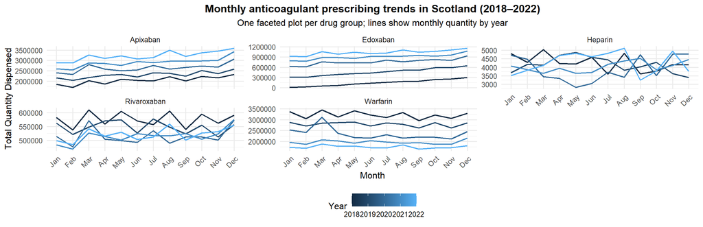

Figure 1: Monthly anticoagulant prescribing trends in Scotland (2018–2022).  
Facets use free y-axes, making the vertical scale different for each drug, therefore comparisons are valid within a panel but not across panels. Source: Public Health Scotland Data by Prescriber Location (2018–2022).

```r
monthly_yearly_data_summary_plot <- monthly_yearly_data_summary %>%
  ggplot(aes(x = Month,
             y = Total_Quantity_Dispensed,
             group = Year,
             colour = Year)) +
  geom_line(linewidth = 0.8) +
  facet_wrap(~ Drug_Group, scales = "free_y") +
  scale_x_discrete(drop = FALSE) +
  labs(
    title    = "Monthly anticoagulant prescribing trends in Scotland (2018–2022)",
    subtitle = "One faceted plot per drug group; lines show monthly quantity by year",
    y        = "Total Quantity Dispensed",
    x        = "Month",
    colour   = "Year"
  ) +
  theme_minimal(base_size = 12) +
  theme(
    axis.text.x   = element_text(angle = 45, hjust = 1, vjust = 1),
    plot.title    = element_text(hjust = 0.5, face = "bold"),
    plot.subtitle = element_text(hjust = 0.5),
    legend.position = "bottom"
  )
print(monthly_yearly_data_summary_plot)
```

## 2.3 Figure 2. Yearly trends in monthly anticoagulant prescribing per drug (2018-2022).

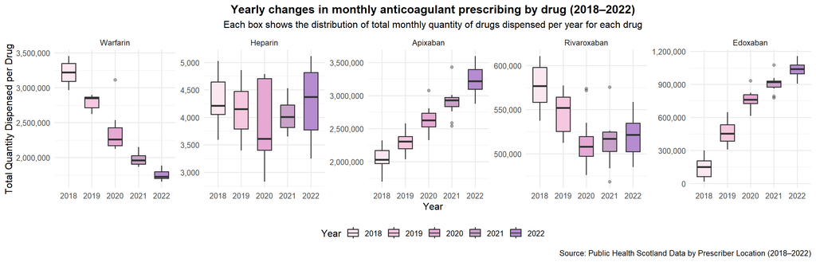

Figure 2: Yearly trends in monthly anticoagulant prescribing per drug (2018-2022).  
Source: Public Health Scotland Data by Prescriber Location (2018–2022).

```r
drug_order <- c("Warfarin","Heparin","Apixaban","Rivaroxaban","Edoxaban")

ggplot(monthly_yearly_data_summary %>%
         filter(Drug_Group %in% drug_order) %>%
         mutate(Drug_Group = factor(Drug_Group, levels = drug_order)), aes(x = factor(Year), y = Total_Quantity_Dispensed , fill = factor(Year))) +
  geom_boxplot(outlier.alpha = 0.4, width = 0.6) +
  facet_wrap(~ Drug_Group, scales = "free_y", nrow = 1) +
  scale_y_continuous(labels = scales::comma) +
  scale_fill_manual(
    values = c("#fbe7f0", "#f6c8e0", "#e5a9d4", "#c8a2c8", "#b58ccf"),
    name = "Year"
  ) +
  labs(
    title = "Yearly changes in monthly anticoagulant prescribing by drug (2018–2022)",
    subtitle = "Each box shows the distribution of total monthly quantity of drugs dispensed per year for each drug",
    x = "Year",
    y = "Total Quantity Dispensed per Drug",
    caption = "Source: Public Health Scotland Data by Prescriber Location (2018–2022)"
  ) +
  theme_minimal(base_size = 12) +
  theme(
    plot.title = element_text(hjust = 0.5, face = "bold"),
    plot.subtitle = element_text(hjust = 0.5),
    legend.position = "bottom"
  )
```

## 2.4 Table 1. Change in anticoagulant prescribing in Scotland between 2018–2022

```r
# Yearly totals per drug
yearly_totals <- monthly_yearly_data_summary %>%
  group_by(Year, Drug_Group) %>%
  summarise(
    Total_Quantity_Dispensed = sum(Total_Quantity_Dispensed, na.rm = TRUE),
    .groups = "drop"
  )

# Wide format table
yearly_wide <- yearly_totals %>%
  pivot_wider(
    names_from  = Drug_Group,
    values_from = Total_Quantity_Dispensed,
    values_fill = 0
  )
# % change 2018 -> 2022 to provide e better insight into how the trend in prescribing these drugs actually changed
vals_2018 <- yearly_wide %>% filter(Year == 2018) %>% select(-Year)
vals_2022 <- yearly_wide %>% filter(Year == 2022) %>% select(-Year)
pct_change <- ((vals_2022 - vals_2018) / vals_2018) * 100 %>% round(1)

# Function to make drug percentages to be able to be inline inserted into the text
fmt <- function(x) {
  out <- sprintf("%.2f", x) #To 2 decimal places
  ifelse(x > 0, paste0("+", out), out) #Generate strings for each anticoagulant drug
}
warfarin_change  <- fmt(pct_change$Warfarin)
heparin_change   <- fmt(pct_change$Heparin)
apixaban_change  <- fmt(pct_change$Apixaban)
rivarox_change   <- fmt(pct_change$Rivaroxaban)
edoxaban_change  <- fmt(pct_change$Edoxaban)

# Make summary row to join to the table later
summary_row <- tibble(Year = "Δ% 2018→2022") %>% bind_cols(pct_change)
yearly_wide_plus <- yearly_wide %>%
  mutate(Year = as.character(Year)) %>%
  bind_rows(summary_row)

drug_cols <- c("Warfarin","Heparin","Apixaban","Rivaroxaban","Edoxaban")

library(glue)

#Create the table
prescription_per_year <-
  yearly_wide_plus %>%
  gt() %>%
  cols_move_to_start(columns = "Year") %>%
  cols_move(columns = "Heparin",     after = "Warfarin") %>%
  cols_move(columns = "Apixaban",    after = "Heparin") %>%
  cols_move(columns = "Rivaroxaban", after = "Apixaban") %>%
  cols_move(columns = "Edoxaban",    after = "Rivaroxaban") %>%
  fmt_number(columns = drug_cols, rows = Year != "Δ% 2018→2022", decimals = 2) %>%
  fmt_number(columns = drug_cols, rows = Year == "Δ% 2018→2022",
             decimals = 1, pattern = "{x}%") %>%
  cols_align(align = "center", columns = everything()) %>%
  data_color(
    columns = drug_cols,
    colors = scales::col_numeric(
      palette = c("#fbe7f0", "#f6c8e0", "#e5a9d4", "#c8a2c8"),
      domain = NULL
    )
  ) %>%
  tab_style(
    style = list(cell_fill(color = "#f7eef7"),
                 cell_text(weight = "bold")),
    locations = cells_body(rows = Year == "Δ% 2018→2022")
  ) %>%
  tab_options(
  table.font.size = px(13),
  data_row.padding = px(3),
  column_labels.font.size = px(12),
  table.width = pct(90)
) %>%
  tab_header(
    title = "Table 1: Anti-coagulant prescribing by year",
    subtitle = glue("Total quantity dispensed per drug, 2018–2022 (with Δ% 2018→2022)")
  )

prescription_per_year
```

Table 1: Anti-coagulant prescribing by year

Total quantity dispensed per drug, 2018–2022 (with Δ% 2018→2022)

| Year | Warfarin | Heparin | Apixaban | Rivaroxaban | Edoxaban |
| --- | --- | --- | --- | --- | --- |
| 2018 | 38,622,568.00 | 51,207.00 | 24,495,059.00 | 6,918,600.28 | 1,739,407.56 |
| 2019 | 33,540,634.31 | 49,734.00 | 27,647,621.81 | 6,577,708.12 | 5,542,940.00 |
| 2020 | 28,217,095.01 | 46,767.00 | 31,628,639.46 | 6,182,230.63 | 9,124,333.84 |
| 2021 | 23,626,677.00 | 48,352.00 | 34,838,802.10 | 6,177,731.00 | 10,860,133.06 |
| 2022 | 21,014,052.87 | 51,240.00 | 38,716,155.32 | 6,260,193.63 | 12,402,187.66 |
| Δ% 2018→2022 | −45.6% | 0.1% | 58.1% | −9.5% | 613.0% |

Table 1 shows trends in anticoagulant prescribing in Scotland between 2018 and 2022, with a marked decrease in Warfarin use (-45.59%), and a substantial increase in DOACs such as Apixaban (+58.06%) and Edoxaban (+613.01%). The exceptionally large percentage increase in Edoxaban reflects its relatively low use in 2018, along with its rapid introduction in subsequent years, especially as DOACs became more favoured during the COVID-19 pandemic. Heparin exhibits almost no overall change in prescribing (+0.06%), pointing towards its stable use in hospital settings. The slight decrease in Rivaroxaban (-9.52%) likely reflects a shift in preference towards Apixaban or Edoxaban. Overall, these patterns further support the pandemic-driven shift in national guidelines from Warfarin to DOACs to minimise in-person blood monitoring requirements.

## 2.5 Merging the anticoagulant and daily COVID-19 admissions datasets to analyse the relationship between anticoagulant prescriptions and COVID-19 hospitalizations.

```r
# Filter anticoagulant data to dates from March 2020 onwards to match the COVID-19 dataset
filtered_anti_coagulant_data <- anti_coagulant_data %>%
  filter(month_date >= as.Date("2020-03-01"))

# Load and aggregate the COVID-19 admissions data to monthly totals
covid19_monthly_admissions <- read_covid_admissions(
  here("data", "daily_covid_admissions_20231004.csv")
)

# Merge monthly COVID-19 admissions with anticoagulant prescribing
merged_anti_coagulant_covid19_admissions <- covid19_monthly_admissions %>%
  full_join(filtered_anti_coagulant_data, join_by(month_date)) #Full join was used to merge the monthly prescribing and COVID-19 datasets to ensure that all months are included, even if one source did not contain data for a particular month.
```

## 2.6 Figure 3. Relationship between COVID-19 hospital admissions and monthly anticoagulant prescribing in Scotland (2020-2022).

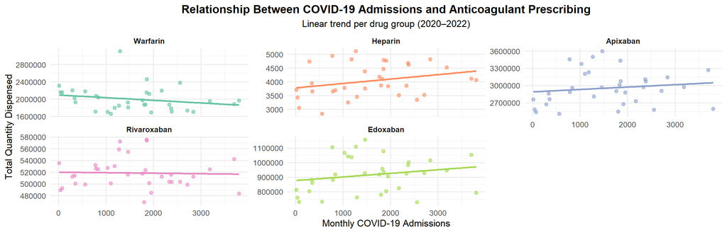

Figure 3: Relationship between COVID-19 hospital admissions and monthly anticoagulant prescribing in Scotland (2020-2022)

```r
# Clean merged data: keep only rows with both admissions and prescribing info
summary_merged_data <- merged_anti_coagulant_covid19_admissions %>%
  filter(
    !is.na(Drug_Group),
    !is.na(monthly_admissions),
    !is.na(paid_quantity)
  ) %>%
  group_by(month_date, Drug_Group) %>%
  summarise(
    monthly_admissions = first(monthly_admissions),
    total_dispensed    = sum(paid_quantity, na.rm = TRUE),
    .groups = "drop"
  ) %>%
  mutate(
    Drug_Group = factor(
      Drug_Group,
      levels = c("Warfarin", "Heparin", "Apixaban", "Rivaroxaban", "Edoxaban")
    )
  )

ggplot(summary_merged_data, aes(x = monthly_admissions, y = total_dispensed, colour = Drug_Group)) +
  geom_point(alpha = 0.6, size = 2) +
  geom_smooth(method = "lm", se = FALSE, linewidth = 1.2) +
  facet_wrap(~ Drug_Group, scales = "free_y", ncol = 3) +
  scale_color_brewer(palette = "Set2") +
  labs(
    title    = "Relationship Between COVID-19 Admissions and Anticoagulant Prescribing",
    subtitle = "Linear trend per drug group (2020–2022)",
    x        = "Monthly COVID-19 Admissions",
    y        = "Total Quantity Dispensed",
    colour   = "Drug Group"
  ) +
  theme_minimal(base_size = 13) +
  theme(
    plot.title    = element_text(hjust = 0.5, face = "bold"),
    plot.subtitle = element_text(hjust = 0.5),
    strip.text    = element_text(face = "bold"),
    legend.position = "none"
  )
```

Figure 3 shows the relationship between monthly COVID-19 hospital admissions and the total quantity dispensed of each anticoagulant drug between 2020 and 2022. Warfarin shows a slight negative relationship, with higher COVID-19 admissions associated with lower prescribing, reflecting the broader decline in its use during the pandemic. Heparin and Edoxaban show a positive relationship, suggesting a potential increase in their use during periods of higher COVID-19 admissions, likely reflecting their use in urgent hospital management and the wider uptake of DOACs. Apixaban and Rivaroxaban show weak associations, demonstrating that their prescribing was overall stable, regardless of monthly COVID-19 admission fluctuations. Overall, these trends showcase that increases in COVID-19 hospital admissions may have had an influence over the use of certain anticoagulants, specifically Heparin and Edoxaban. Importantly, these trends reflect association rather than causation.

# 3 Discussion & Conclusion

This investigation demonstrated a clear change in anticoagulant prescribing patterns in Scotland between 2018 and 2022, corresponding with the onset and progression of the COVID-19 pandemic. Prescriptions for Warfarin significantly declined over the years, while the use of direct oral anticoagulants (DOACs) such as Apixaban and Edoxaban sharply increased. These findings are in line with national guidance established during the pandemic, encouraging a prescribing switch from Warfarin to DOACs to reduce in-person monitoring and maintain proper anticoagulant patient care under lockdown conditions. The visual relationship between higher COVID-19 admissions and increased use of certain anticoagulants like Heparin and Edoxaban, suggests that pandemic-related hospital demands may also have influenced prescribing behaviour.

Nevertheless, this investigation is limited by its national breadth and lack of demographic or regional data inclusion. It fails to distinguish whether changes in trends were as a result of changes in hospital protocols, primary care adaptations, or patient-derived factors. Future investigations could incorporate geographical or population-level data (e.g., GP practice or health board information) to further explore local variations.

# 4 References

1. Curtis, H. J., MacKenna, B., Walker, A. J., Croker, R., Mehrkar, A., Morton, C., Bacon, S., Hickman, G., Inglesby, P., Bates, C., Evans, D., Ward, T., Cockburn, J., Davy, S., Bhaskaran, K., Schultze, A., Rentsch, C. T., Williamson, E., Hulme, W., … Goldacre, B. (2021). OpenSAFELY: Impact of national guidance on switching anticoagulant therapy during COVID-19 pandemic. Open Heart, 8(2). https://doi.org/10.1136/openhrt-2021-001784
2. Elezkurtaj, S., Greuel, S., Ihlow, J., Michaelis, E. G., Bischoff, P., Kunze, C. A., Sinn, B. V., Gerhold, M., Hauptmann, K., Ingold-Heppner, B., Miller, F., Herbst, H., Corman, V. M., Martin, H., Radbruch, H., Heppner, F. L., & Horst, D. (2021). Causes of death and comorbidities in hospitalized patients with covid-19. Scientific Reports, 11(1). https://doi.org/10.1038/s41598-021-82862-5
3. Kichloo, A., Dettloff, K., Aljadah, M., Albosta, M., Jamal, S., Singh, J., Wani, F., Kumar, A., Vallabhaneni, S., & Khan, M. Z. (2020). Covid-19 and hypercoagulability: A Review. Clinical and Applied Thrombosis/Hemostasis, 26. https://doi.org/10.1177/1076029620962853
4. Mohseni Afshar, Z., Tavakoli Pirzaman, A., Hosseinzadeh, R., Babazadeh, A., Taghizadeh Moghadam, M. A., Miri, S. R., Sio, T. T., Sullman, M. J., Barary, M., & Ebrahimpour, S. (2023). Anticoagulant therapy in covid‐19: A narrative review. Clinical and Translational Science, 16(9), 1510–1525. https://doi.org/10.1111/cts.13569
5. Sutanto, H., & Soegiarto, G. (2023). Risk of thrombosis during and after a SARS-COV-2 infection: Pathogenesis, Diagnostic Approach, and Management. Hematology Reports, 15(2), 225–243. https://doi.org/10.3390/hematolrep15020024